# Alumnos - Nutrición 2014

## Descripción

Aquí presentamos los resultados de las encuestas de `evaluación institucional` llevada a cabo en mayo del 2014 en la que se recabaron datos de los alumnos de la carrera de `Nutrición` de la Facultad de Medicina (Sede Asunción) de la Universidad del Norte. La encuesta consistió en un formulario de `91 preguntas` evaluando cada una de las siguientes dimensiones:

- Dimensión 1: Organización & Gestión
  - 1.1: Organización
  - 1.2: Gestión
- Dimensión 2: Proyecto Académico
  - 2.1: Objetivos de carrerra y Perfil de Egreso
  - 2.2: Plan de estudios
  - 2.3: Proceso enseñanza-aprendizaje
  - 2.4: Evaluación del proceso enseñanza-aprendizaje
  - 2.5: Investigación y extensión
- Dimensión 3: Personas
  - 3.1: Directivos
  - 3.2: Docentes
  - 3.3: Estudiantes
  - 3.4: Personal administrativo y de apoyo
- Dimensión 4: Recursos
  - 4.1: Infraestructura, equipamientos e insumos

El formulario de encuesta también incluyó preguntas acerca del `Año` (1º, 2º, 3º, 4º) en curso y el `Turno` (mañana, tarde, noche) del estudiante. Se obtuvieron `282` formularios de respuestas, los cuales fueron cargados en una base de datos en formato `.csv` para su análisis estadístico. Los datos fueron preprocesados y analizados con [R](http://www.r-project.org) versión 3.1.0. Este documento fue redactado utilizando MarkDown en [RStudio](http://www.rstudio.com) versión 0.98.501 y el paquete [knitr](http://cran.r-project.org/web/packages/knitr/index.html) versión 1.6 de [Yihui Xie](http://yihui.name/knitr).

## Preprocesamiento de datos

Primero cargamos la base de datos:

```r
data.alumnos <- read.csv("../Central - Nutrición - Alumnos - Dimensión 1.csv")
```

Excluimos la pregunta Q2.25.k (“En caso afirmativo, indicar …”) por no corresponder al diseño apropiado:

```r
data.alumnos <- data.alumnos[, -54]
```

Convertimos todos los valores perdidos en `4`, basándonos en la interpretación de que si el alumno no completa la pregunta es porque no sabe la respuesta o no tiene una opinión al respecto:

```r
data.alumnos[is.na(data.alumnos)] <- 4
```

Recodificamos todos los niveles para todas las variables que representan preguntas, utilizando las etiquetas establecidas en el formulario:

```r
for (i in 4:93) {
    data.alumnos[, i] <- factor(data.alumnos[, i], labels = c(`1` = "Sí", `2` = "No",
        `3` = "En parte", `4` = "Sin opinión/No sabe"))
}
```

Arreglamos el nombre de las columnas para hacerlas más legibles y solucionamos errores en la denominación de las columnas:

```r
columnas <- colnames(data.alumnos)
columnas <- gsub("X1", "Q", x = columnas)
columnas <- gsub("X2", "Q", x = columnas)
columnas <- gsub("X3", "Q", x = columnas)
columnas <- gsub("X4", "Q", x = columnas)
columnas <- gsub(".", "", x = columnas, fixed = TRUE)
columnas <- gsub("Q23f1", "Q25f", x = columnas, fixed = TRUE)
columnas <- gsub("Año", "Curso", x = columnas, fixed = TRUE)
colnames(data.alumnos) <- c(columnas)
```

Reordenamos los niveles del `Año` y `Turno` en el orden creciente correcto:

```r
data.alumnos$Curso <- factor(data.alumnos$Curso, levels(data.alumnos$Curso)[c(2:4,
    1)])
data.alumnos$Turno <- factor(data.alumnos$Turno, levels(data.alumnos$Turno)[c(1,
    3, 2)])
```

Cargamos las preguntas contenidas en el formulario:

```r
source("AlumnosQ.R")
```

## Resultados

Para la presentación de los resultados utilizaremos gráficos de barras, según la siguiente función:

```r
Q.plots <- function(x, y) {
    table.Q <- prop.table(table(x)) * 100
    par(mar = c(2, 5, 7, 2) + 0.1)
    plot.Q <- barplot(table.Q, main = y, cex.main = 2, col = terrain.colors(9),
        ylab = "% Alumnos", cex.lab = 1.5, cex.axis = 1.2, cex.names = 1.5)
    text(plot.Q, 2, round(table.Q, 1), cex = 1.5)
}
```

Las distribuciones por `Año` en curso y `Turno` fueron las siguientes:

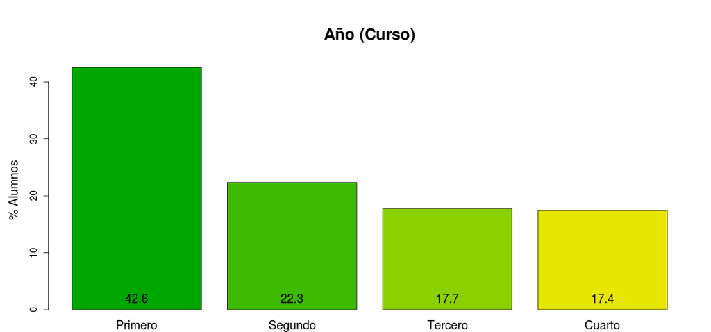

```r
Q.plots(data.alumnos$Curso, Curso)
```

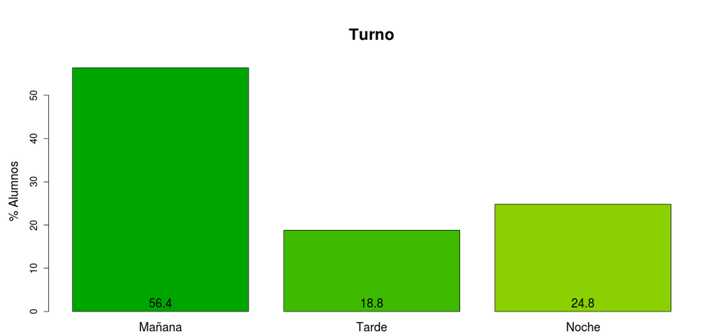

```r
Q.plots(data.alumnos$Turno, Turno)
```

A continuación presentarmos los resultados de las respuestas dadas por los estudiantes.

### Dimensión 1.1 - Organización

Los resultados de esta dimensión son los siguientes:

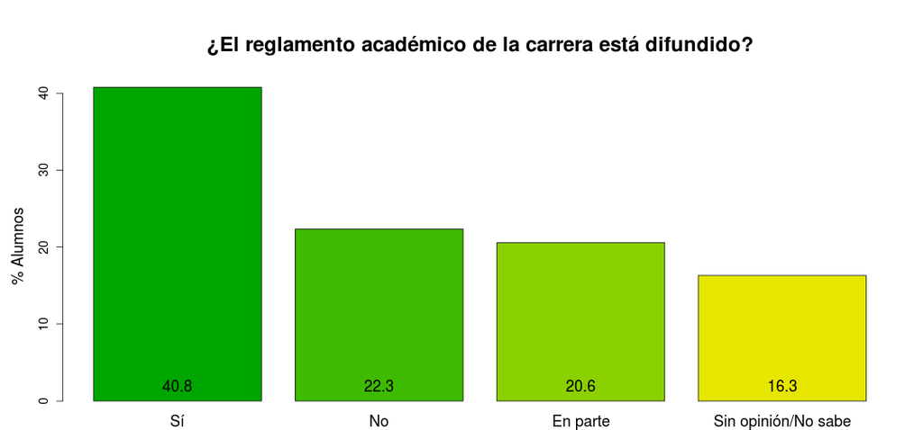

```r
Q.plots(data.alumnos$Q11a, Q11a)
```

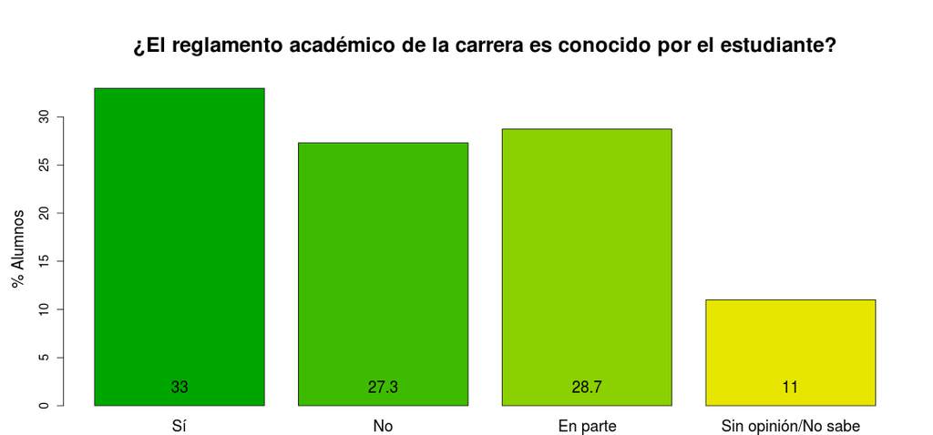

```r
Q.plots(data.alumnos$Q11b, Q11b)
```

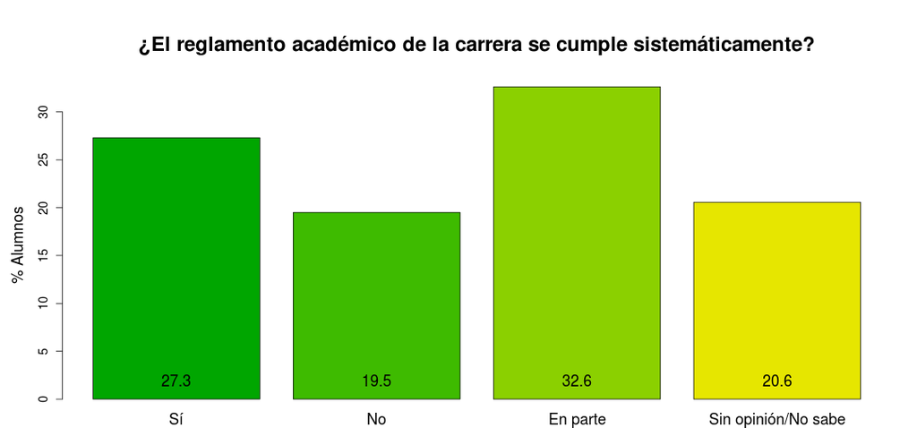

```r
Q.plots(data.alumnos$Q11c, Q11c)
```

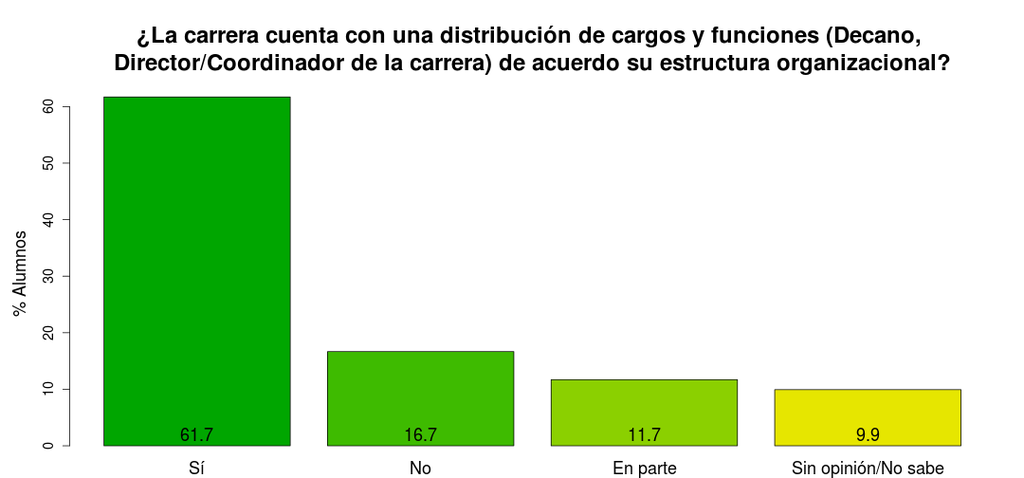

```r
Q.plots(data.alumnos$Q11d, Q11d)
```

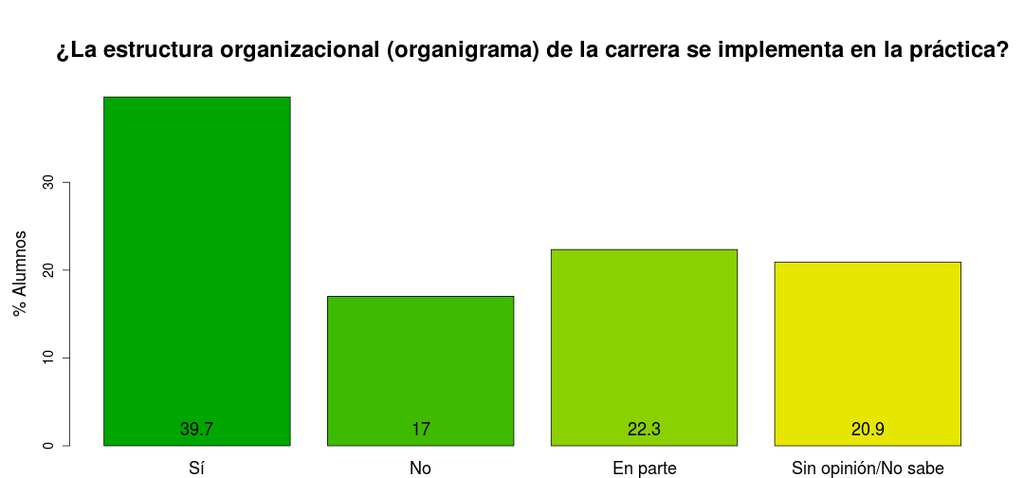

```r
Q.plots(data.alumnos$Q11e, Q11e)
```

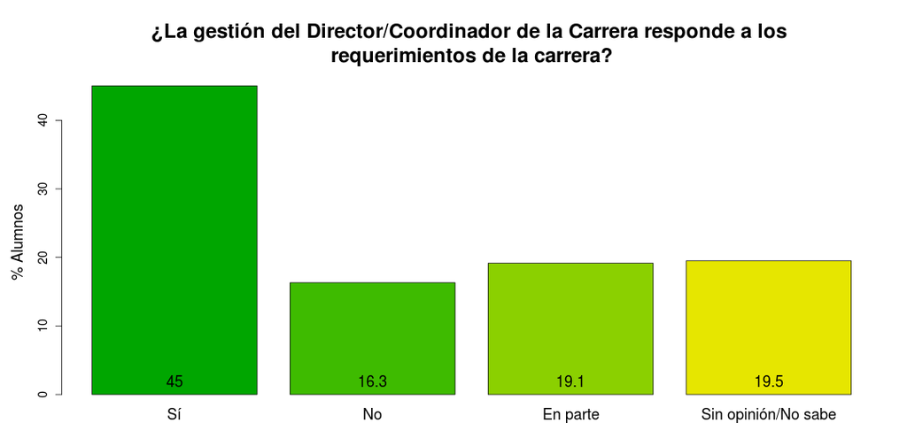

```r
Q.plots(data.alumnos$Q11f, Q11f)
```

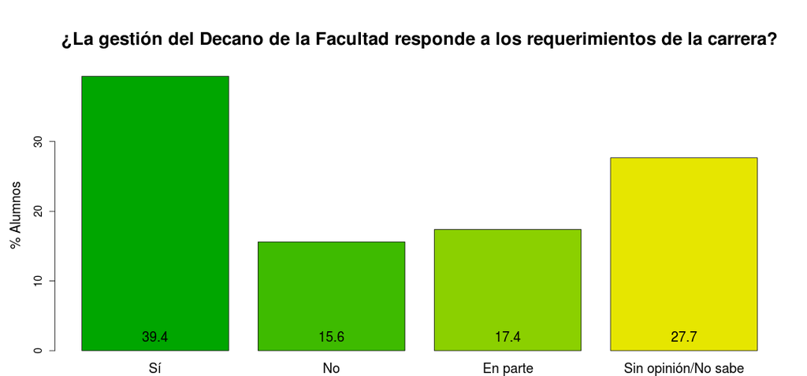

```r
Q.plots(data.alumnos$Q11g, Q11g)
```

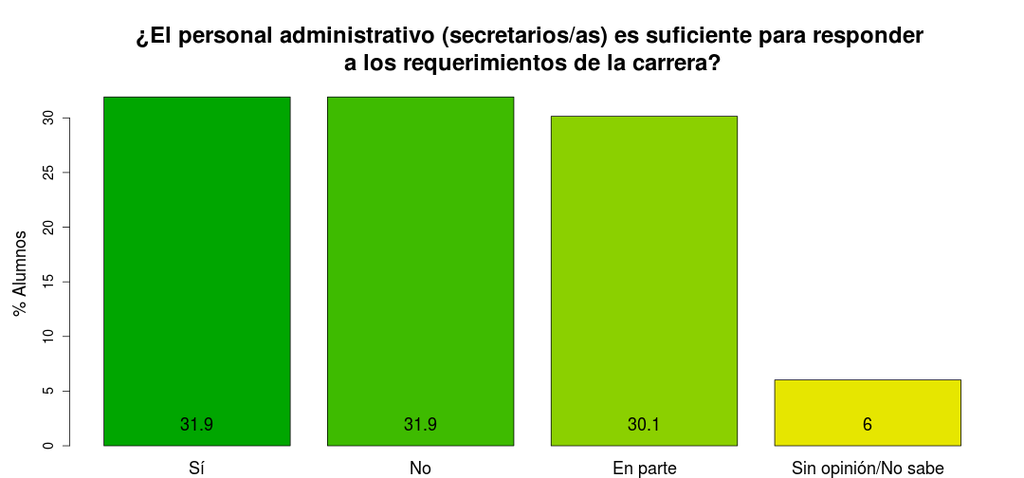

```r
Q.plots(data.alumnos$Q11h, Q11h)
```

### Dimensión 1.2 - Gestión

Los resultados de esta dimensión son los siguientes:

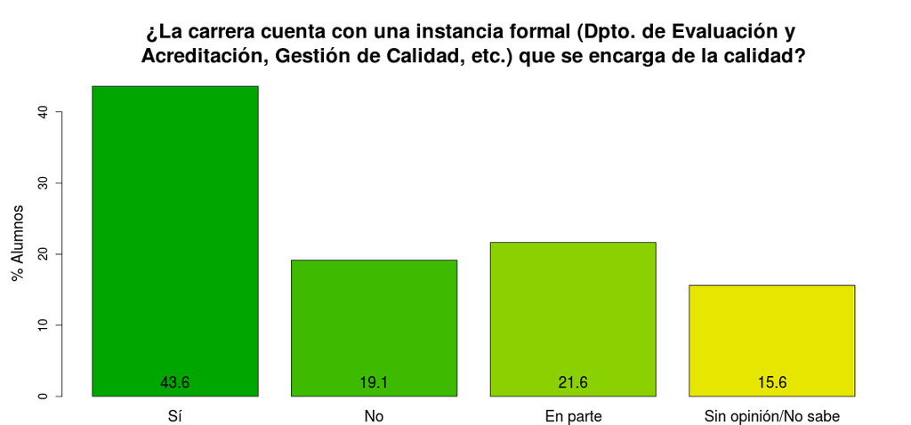

```r
Q.plots(data.alumnos$Q12a, Q12a)
```

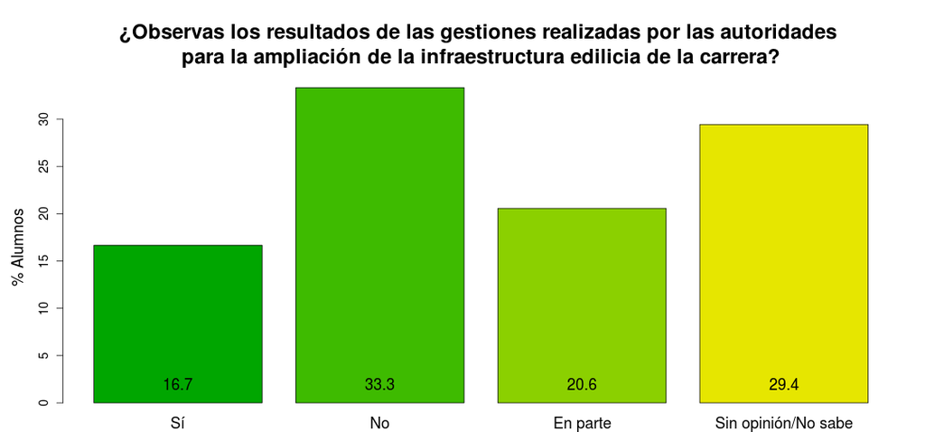

```r
Q.plots(data.alumnos$Q12b, Q12b)
```

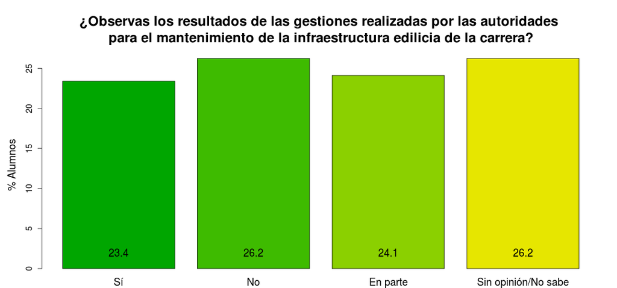

```r
Q.plots(data.alumnos$Q12c, Q12c)
```

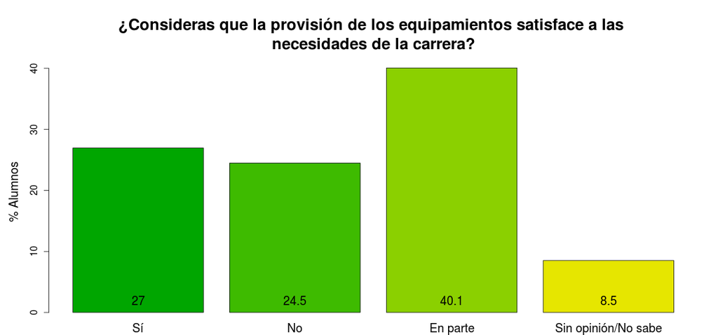

```r
Q.plots(data.alumnos$Q12d, Q12d)
```

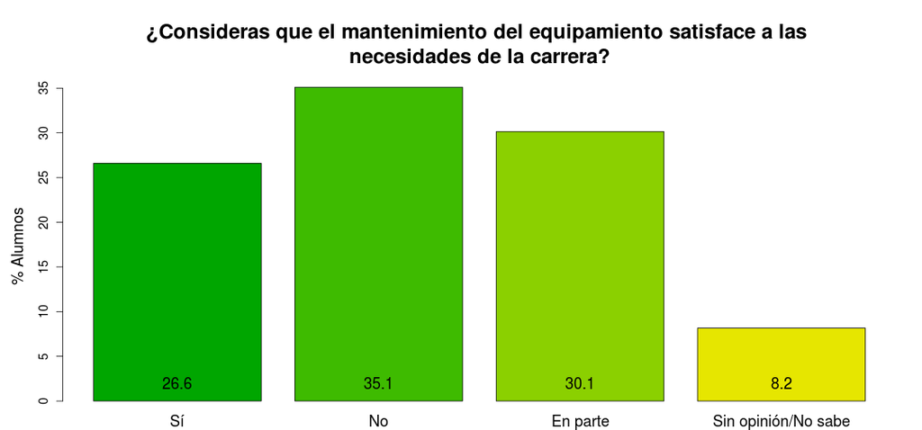

```r
Q.plots(data.alumnos$Q12e, Q12e)
```

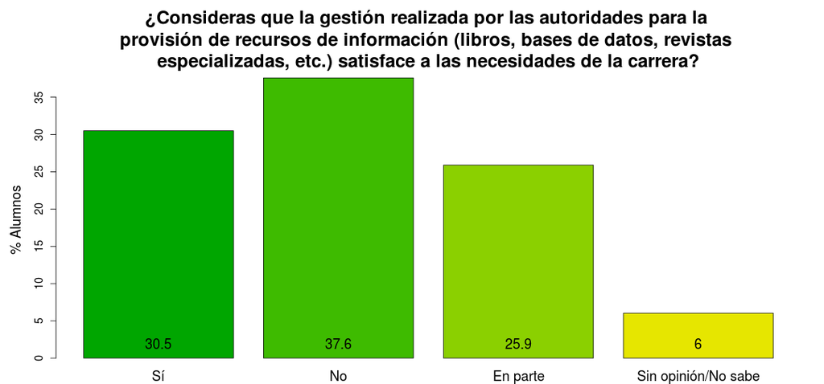

```r
Q.plots(data.alumnos$Q12f, Q12f)
```

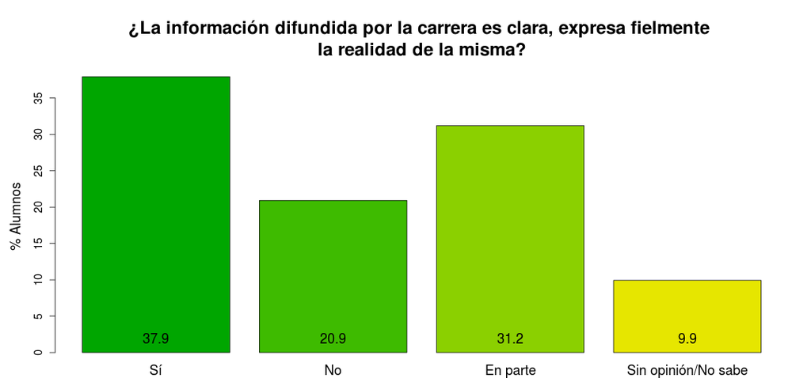

```r
Q.plots(data.alumnos$Q12g, Q12g)
```

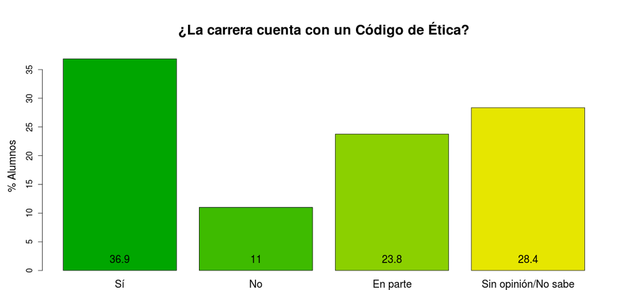

```r
Q.plots(data.alumnos$Q12h, Q12h)
```

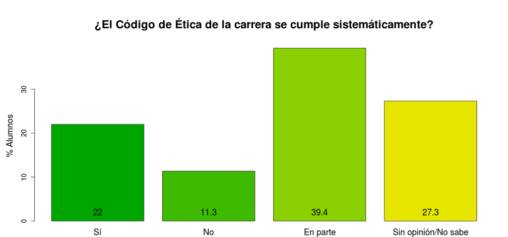

```r
Q.plots(data.alumnos$Q12i, Q12i)
```

### Dimensión 2.1 - Objetivos de la carrera y Perfil de Egreso

Los resultados de esta dimensión son los siguientes:

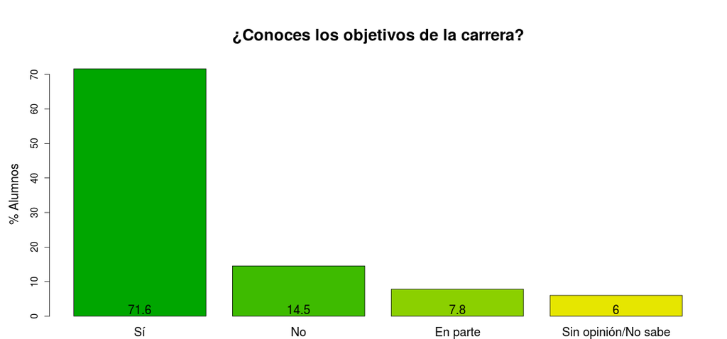

```r
Q.plots(data.alumnos$Q21a, Q21a)
```

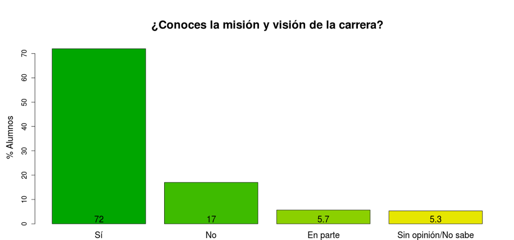

```r
Q.plots(data.alumnos$Q21b, Q21b)
```

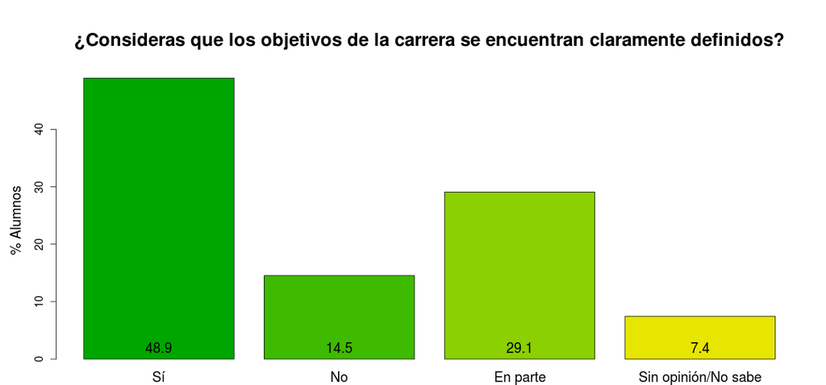

```r
Q.plots(data.alumnos$Q21c, Q21c)
```

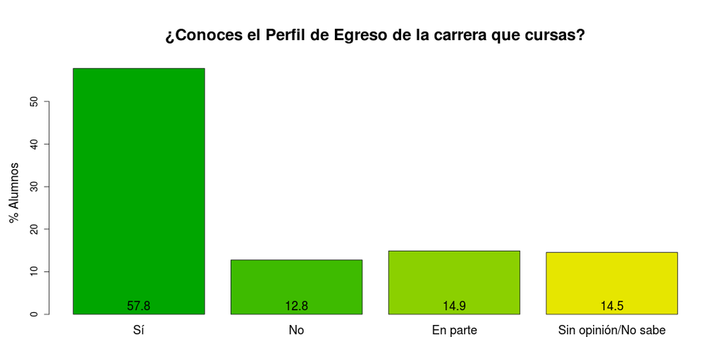

```r
Q.plots(data.alumnos$Q21d, Q21d)
```

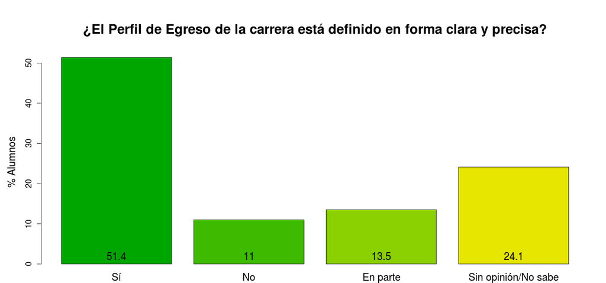

```r
Q.plots(data.alumnos$Q21e, Q21e)
```

### Dimensión 2.2 - Plan de Estudios

Los resultados de esta dimensión son los siguientes:

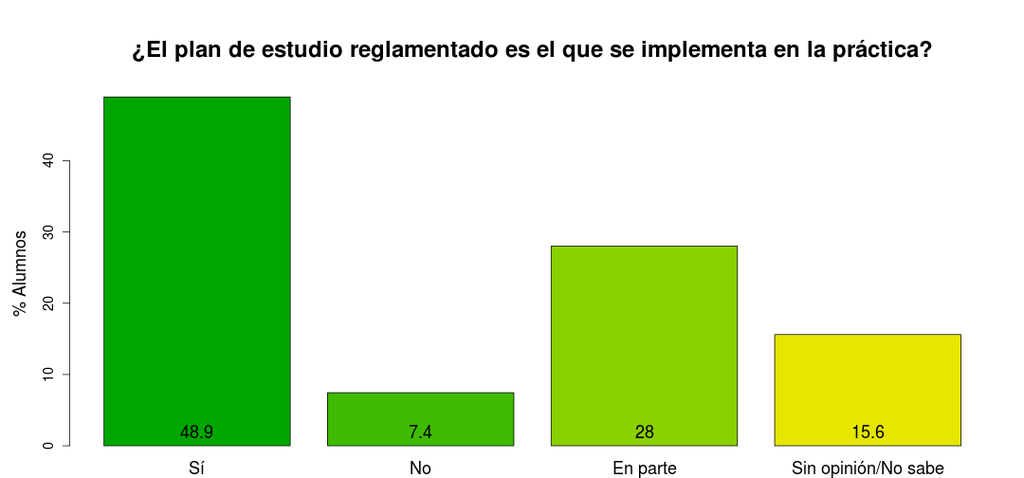

```r
Q.plots(data.alumnos$Q22a, Q22a)
```

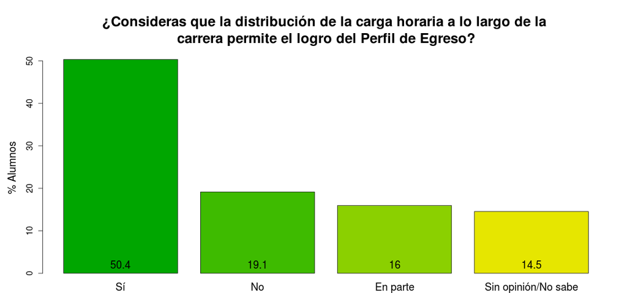

```r
Q.plots(data.alumnos$Q22b, Q22b)
```

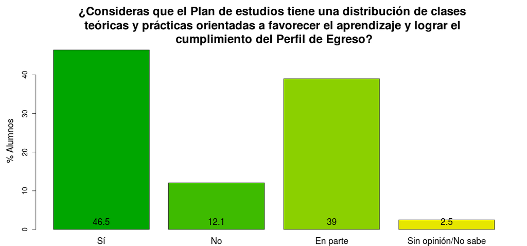

```r
Q.plots(data.alumnos$Q22c, Q22c)
```

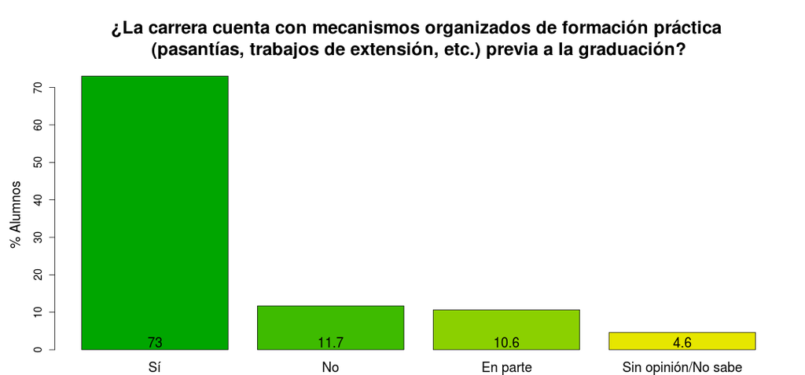

```r
Q.plots(data.alumnos$Q22d, Q22d)
```

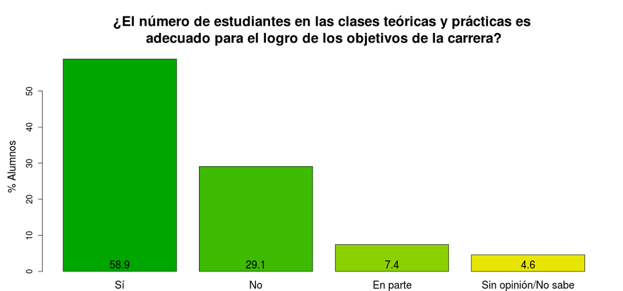

```r
Q.plots(data.alumnos$Q22e, Q22e)
```

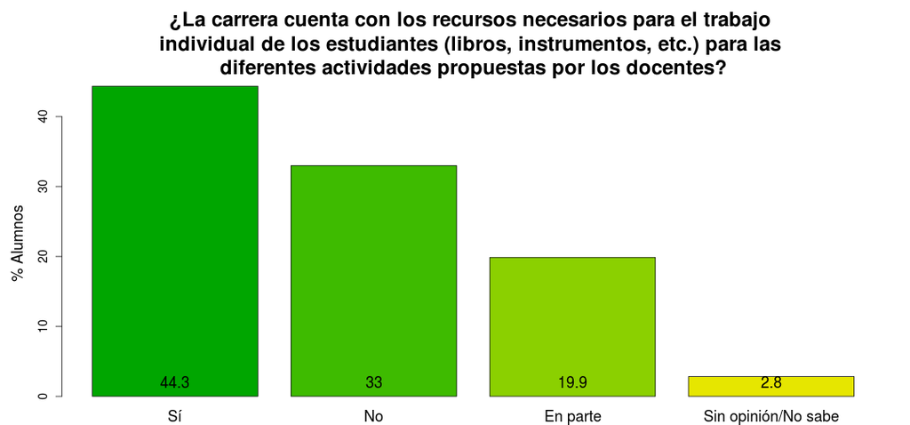

```r
Q.plots(data.alumnos$Q22f, Q22f)
```